# Stress, employment, and family life in Covid-19

Elena Leib

10/14/2021

```r
# To prep the data, we want to select our variables of interest:
# household_children
# Sum score of child_education_[1-4]
# i10_health
# i11_health
# r1_1
# WCRV_4
# cantril_ladder
# Sum score of PHQ4_[1-4]
# CORE_B2_4
# w4_[1-11] <-- Not including work for now!

covid.q3 <- covid_recode %>%
  select(
    gender,
    employment_status,
    PHQ4_1,
    PHQ4_2,
    PHQ4_3,
    PHQ4_4,
    PHQ4_sum,
    household_children,
    # child_education_sum, # Sadly, there are 11057 NAs....
    i10_health,
    i11_health,
    # r1_1, # 3432 NAs
    # WCRV_4, # 7124 NAs
    cantril_ladder,
    # CORE_B2_4, # 7574 NAs
    state,
    age,
    qweek
  ) %>%
  filter(household_children > 0)


covid.q3_noNA <- covid.q3 %>% drop_na()
```

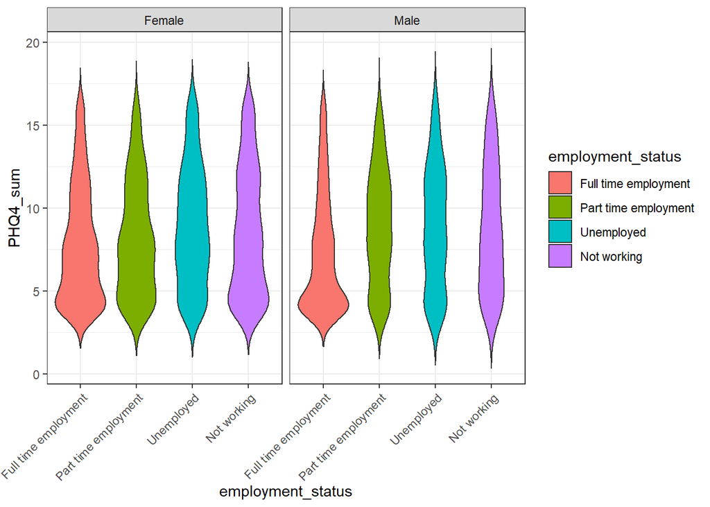

```r
df.violins <- covid.q3_noNA %>%
  filter(employment_status %in% c("Full time employment", "Part time employment",
                                  "Unemployed", "Not working")) %>%
  mutate(employment_status = factor(employment_status, levels =
                                      c("Full time employment", "Part time employment",
                                  "Unemployed", "Not working"))) # %>%
  # recode(employment_status, "Full time employment" = "full-time",
  #        "Part time employment" = "part-time",
  #        "Unemployed" = "unemployed",
  #        "Not working" = "not working")

ggplot(df.violins, aes(x = employment_status, y = PHQ4_sum, fill = employment_status)) +
  facet_wrap(~gender) +
  geom_violin(trim = FALSE) +
  # geom_quasirandom(width=.3, alpha=.2) +
  # geom_beeswarm() +
  theme_bw() +
  theme(axis.text.x=element_text(angle = 45, hjust = 1))
```

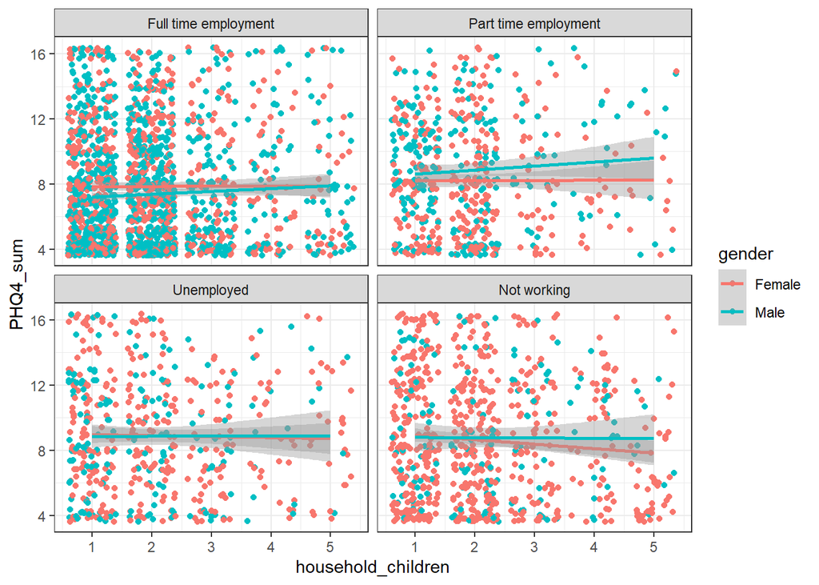

```r
ggplot(df.violins, aes(x = household_children, y = PHQ4_sum, color=gender)) +
  facet_wrap(~employment_status) +
  geom_jitter() +
  geom_smooth(method = "lm") +
  # geom_quasirandom(width=.3, alpha=.2) +
  # geom_beeswarm() +
  theme_bw()
```

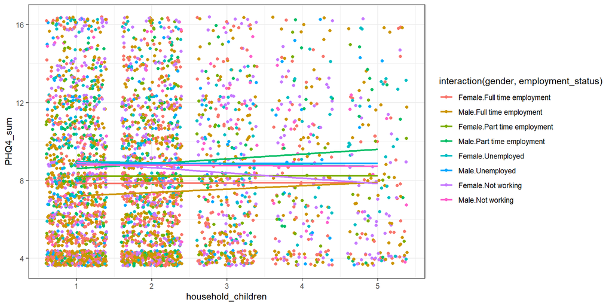

```r
ggplot(df.violins, aes(x = household_children, y = PHQ4_sum,
                       color=interaction(gender, employment_status))) +
  # facet_wrap(~employment_status) +
  geom_jitter() +
  geom_smooth(method = "lm", se = FALSE) +
  # geom_quasirandom(width=.3, alpha=.2) +
  # geom_beeswarm() +
  theme_bw()
```

Dataset: All participants that have at least 1 child in their household under the age of 18, and valid data for all of our measures of interest

#### Across all employment statuses

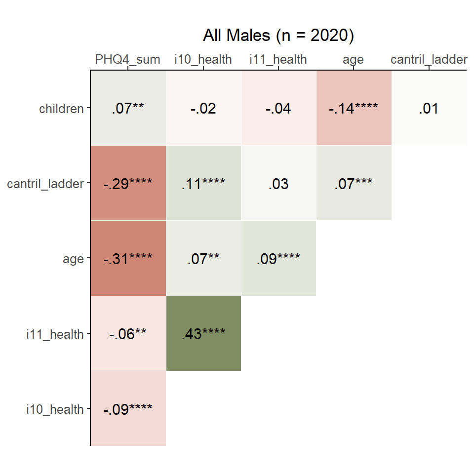

```r
# Now it is time to run the code and make the corrplots!
# Call the makeCorrPlot function on the formatted for cor data. I chose to do
# that all in one step here.

# All males
makeCorrPlot(formatted_cors_rmLower(covid_corrData_m, factorOrder), "All Males", showLeg = FALSE, customLabels = TRUE, xaxisLabs, yaxisLabs, n = nrow(covid_corrData_m))
```

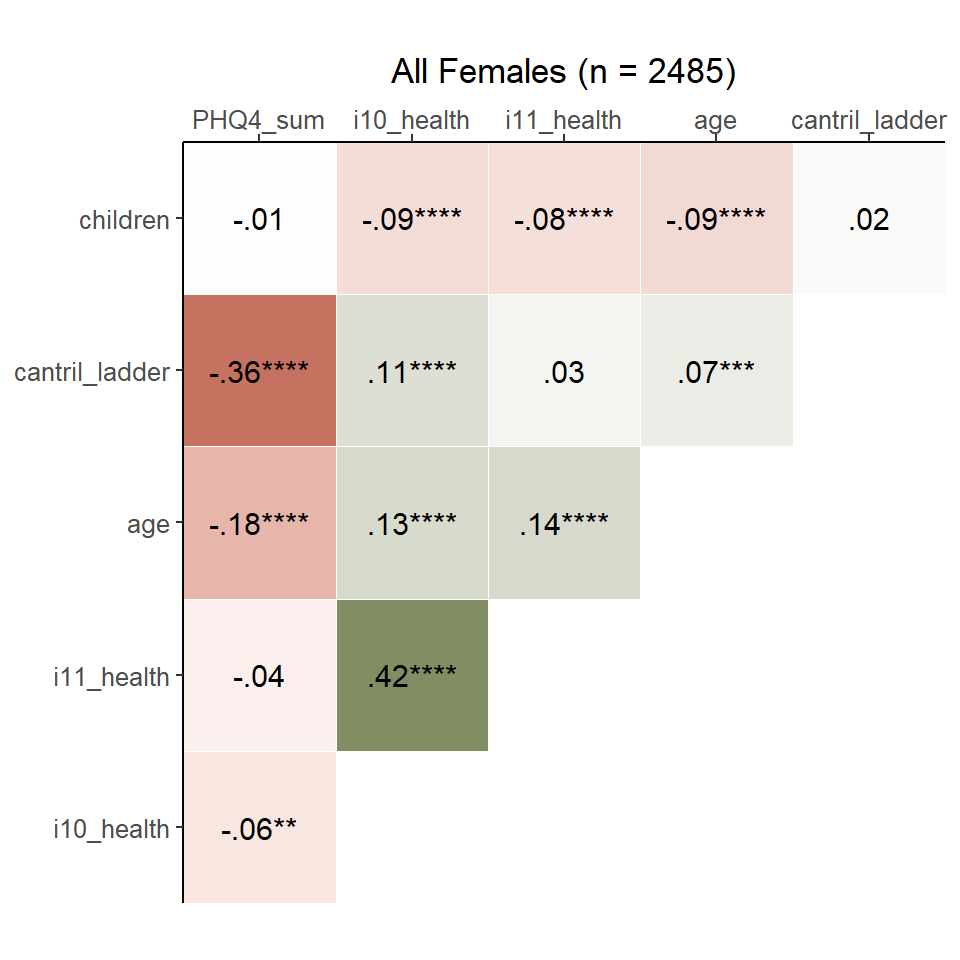

```r
# All females
makeCorrPlot(formatted_cors_rmLower(covid_corrData_f, factorOrder), "All Females", showLeg = FALSE, customLabels = TRUE, xaxisLabs, yaxisLabs, n = nrow(covid_corrData_f))
```

#### Full-time

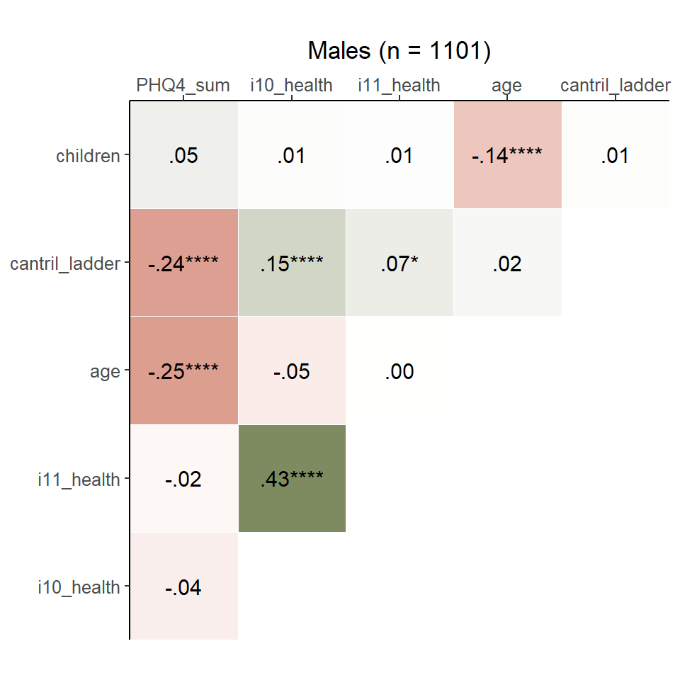

```r
# All males
makeCorrPlot(formatted_cors_rmLower(covid_corrData_m.f, factorOrder), "Males", showLeg = FALSE, customLabels = TRUE, xaxisLabs, yaxisLabs, n = nrow(covid_corrData_m.f))
```

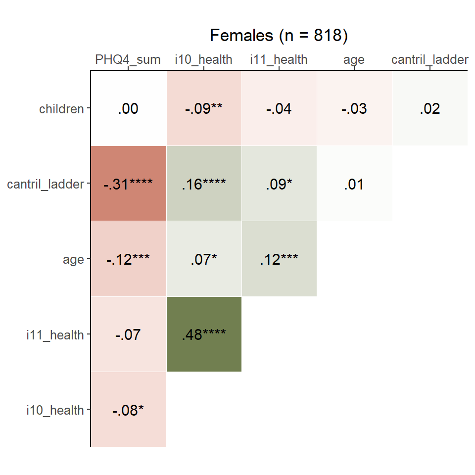

```r
# All females
makeCorrPlot(formatted_cors_rmLower(covid_corrData_f.f, factorOrder), "Females", showLeg = FALSE, customLabels = TRUE, xaxisLabs, yaxisLabs, n = nrow(covid_corrData_f.f))
```

#### Part-time

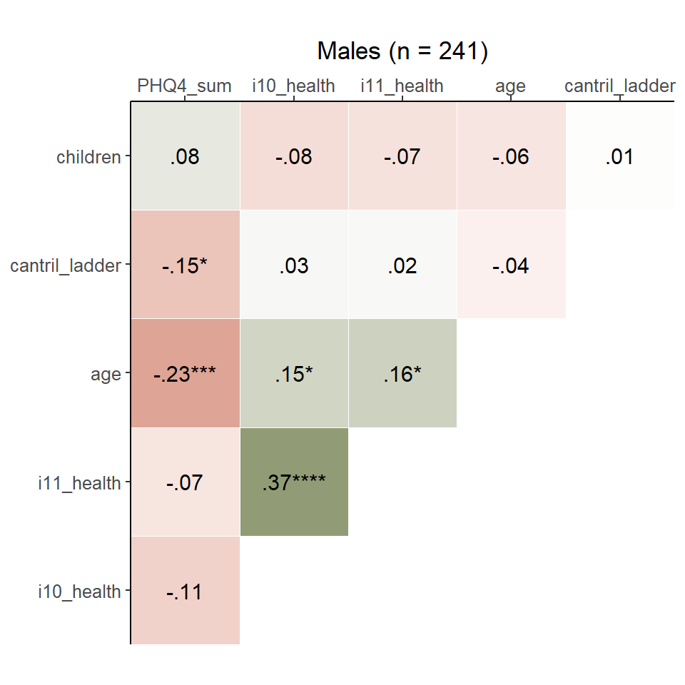

```r
# All males
makeCorrPlot(formatted_cors_rmLower(covid_corrData_m.p, factorOrder), "Males", showLeg = FALSE, customLabels = TRUE, xaxisLabs, yaxisLabs, n = nrow(covid_corrData_m.p))
```

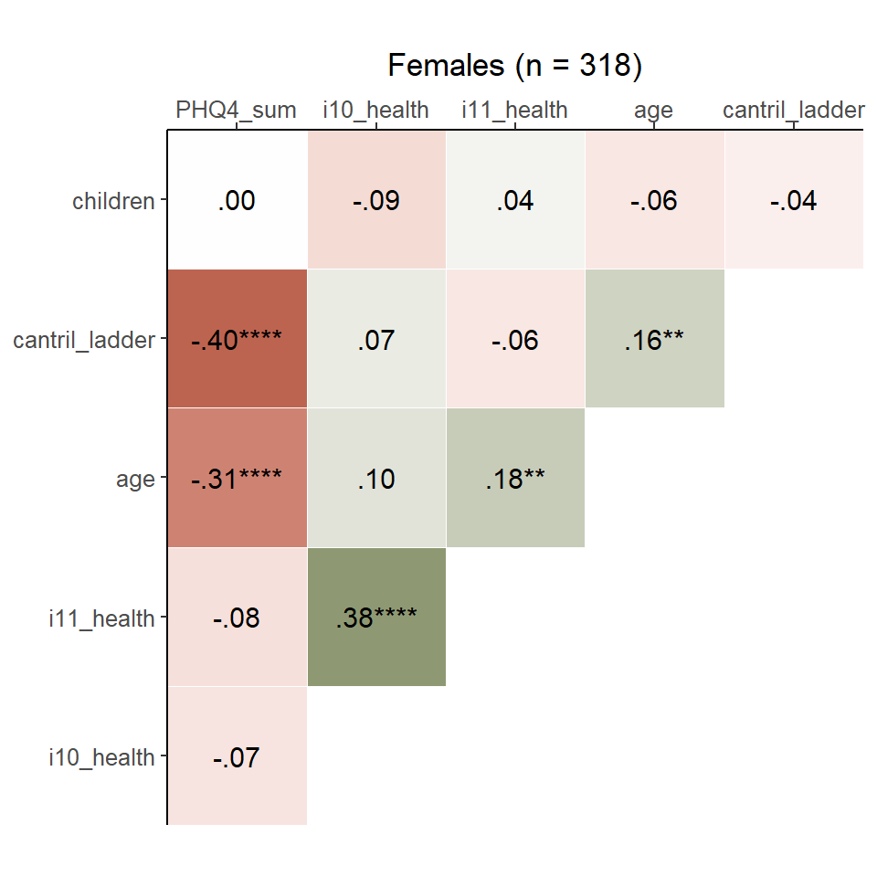

```r
# All females
makeCorrPlot(formatted_cors_rmLower(covid_corrData_f.p, factorOrder), "Females", showLeg = FALSE, customLabels = TRUE, xaxisLabs, yaxisLabs, n = nrow(covid_corrData_f.p))
```

#### Unemployed

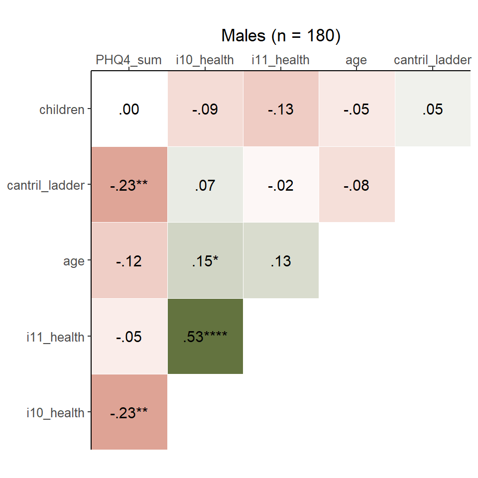

```r
# All males
makeCorrPlot(formatted_cors_rmLower(covid_corrData_m.u, factorOrder), "Males", showLeg = FALSE, customLabels = TRUE, xaxisLabs, yaxisLabs, n = nrow(covid_corrData_m.u))
```

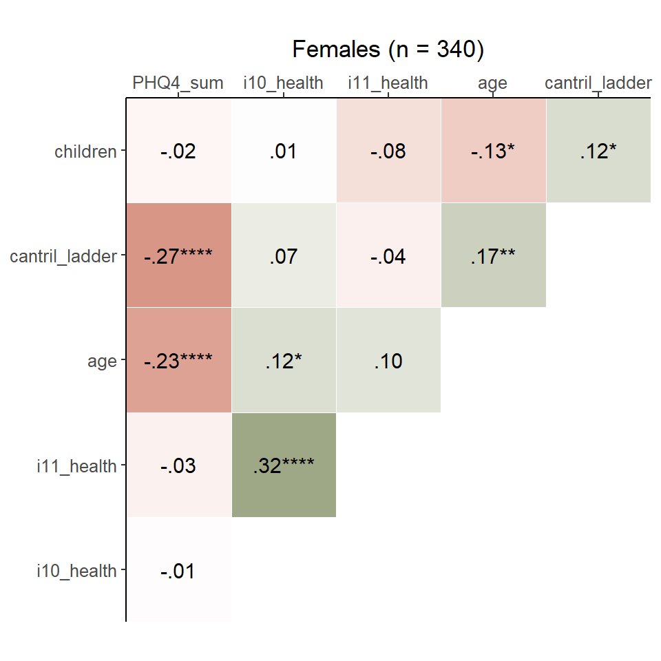

```r
# All females
makeCorrPlot(formatted_cors_rmLower(covid_corrData_f.u, factorOrder), "Females", showLeg = FALSE, customLabels = TRUE, xaxisLabs, yaxisLabs, n = nrow(covid_corrData_f.u))
```

#### Not working

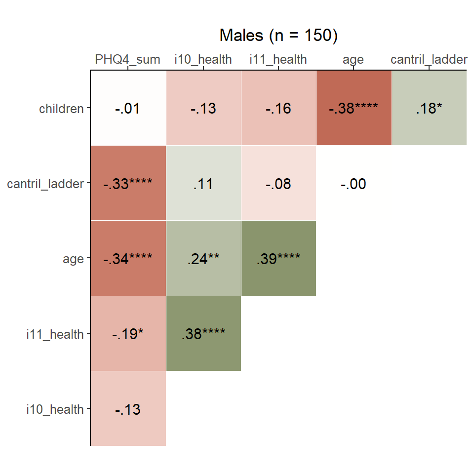

```r
# All males
makeCorrPlot(formatted_cors_rmLower(covid_corrData_m.n, factorOrder), "Males", showLeg = FALSE, customLabels = TRUE, xaxisLabs, yaxisLabs, n = nrow(covid_corrData_m.n))
```

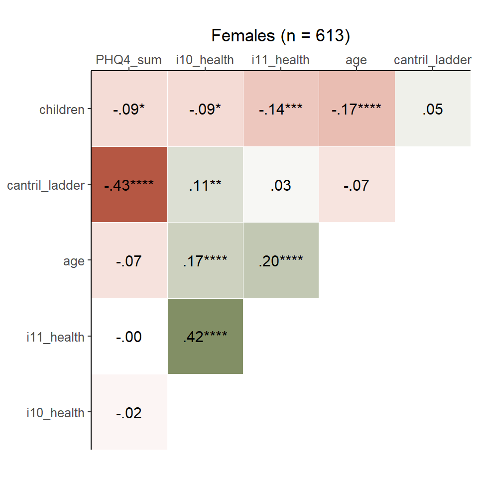

```r
# All females
makeCorrPlot(formatted_cors_rmLower(covid_corrData_f.n, factorOrder), "Females", showLeg = FALSE, customLabels = TRUE, xaxisLabs, yaxisLabs, n = nrow(covid_corrData_f.n))
```

#### Look at relation between cantril_ladder and PHQ4_sum

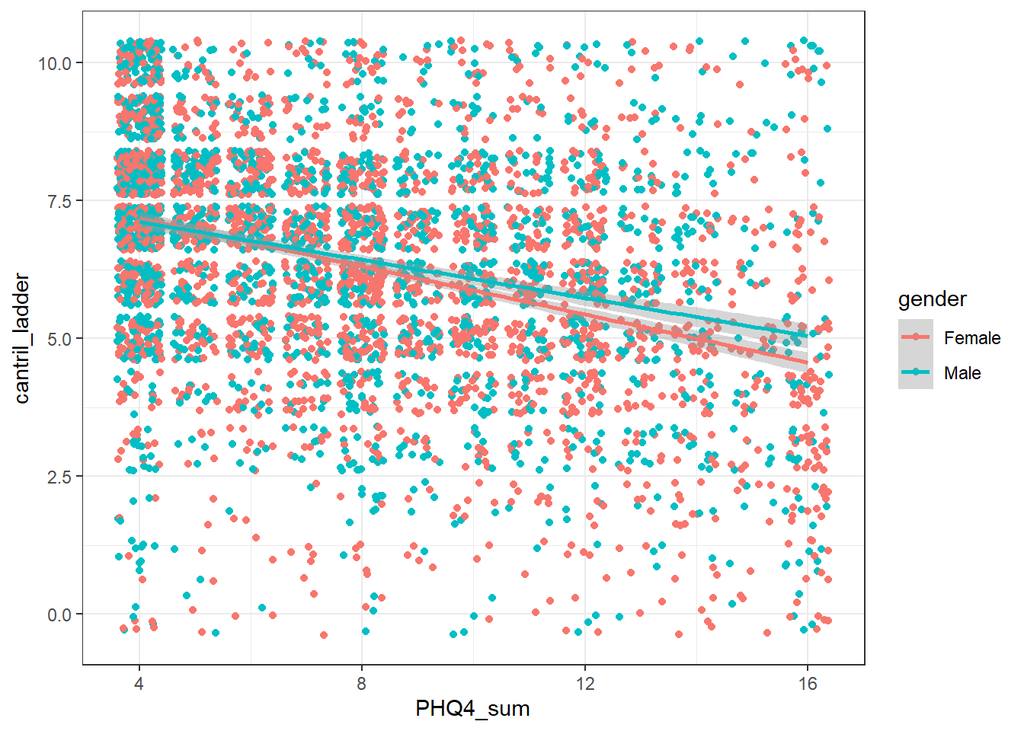

```r
ggplot(covid.q3_noNA, aes(x = PHQ4_sum, y = cantril_ladder, color = gender)) +
  geom_jitter() +
  geom_smooth(method = "lm") +
  theme_bw()
```

#### Run our model of interest

Use all data, don’t filter >1 dependent… include everyone!

```r
df.forAnalysis <- covid_recode %>%
  filter(employment_status %in% c("Full time employment", "Part time employment",
                                  "Unemployed", "Not working")) %>%
  mutate(employment_status = factor(employment_status, levels =
                                      c("Full time employment", "Part time employment",
                                  "Unemployed", "Not working")))



mod <- lm(PHQ4_sum ~ household_children*gender*employment_status + age + week, data = df.forAnalysis)

paste("Our sample size for this analysis:", length(mod$fitted.values), "participants")
```

```
## [1] "Our sample size for this analysis: 12218 participants"
```

```r
export_summs(mod, error_format = "[{conf.low}, {conf.high}]", error_pos = "same", results = "asis")
```

|  | Model 1 |
| --- | --- |
| (Intercept) | 10.19 *** [9.90, 10.49] |
| household_children | 0.03 [-0.08, 0.15] |
| genderMale | -0.74 *** [-0.96, -0.53] |
| employment_statusPart time employment | 0.33 * [0.02, 0.64] |
| employment_statusUnemployed | 1.30 *** [1.00, 1.59] |
| employment_statusNot working | 1.33 *** [1.08, 1.58] |
| age | -0.06 *** [-0.06, -0.05] |
| week | -0.00 [-0.01, 0.01] |
| household_children:genderMale | 0.11 [-0.04, 0.27] |
| household_children:employment_statusPart time employment | 0.01 [-0.21, 0.22] |
| household_children:employment_statusUnemployed | -0.18 [-0.38, 0.01] |
| household_children:employment_statusNot working | -0.29 *** [-0.45, -0.12] |
| genderMale:employment_statusPart time employment | 0.38 [-0.07, 0.83] |
| genderMale:employment_statusUnemployed | -0.28 [-0.71, 0.15] |
| genderMale:employment_statusNot working | 0.68 *** [0.28, 1.08] |
| household_children:genderMale:employment_statusPart time employment | 0.25 [-0.07, 0.56] |
| household_children:genderMale:employment_statusUnemployed | 0.22 [-0.09, 0.53] |
| household_children:genderMale:employment_statusNot working | 0.14 [-0.14, 0.42] |
| N | 12218 |
| R2 | 0.09 |
| *** p < 0.001; ** p < 0.01; * p < 0.05. |  |

Findings:  
- No main effect of # of children on PHQ4 for the full-time group for women  
- Main effect of gender (Males lower on PHQ4)  
- Main effect of employment status: Part-time, Unemployed, and Not Working all have greater PHQ4 than Full-time  
- Main effect of age: small but robust effect, where the older you are, the less stressed you are.  
- No linear effect of week… buuuutttt it’s probably not a linear effect anyway, so would need to model this differently  
- Interaction between # of children and employment status not working for women: Negative relation between # of children and PHQ4 for not working group (more children, less stress/anxiety for this group… curious!)  
- Interaction between genderMale and Not working –> Men who are not working are MORE stressed/anxious than women who are not working!  
- NO 3-way interactions  
(Need to check all these interpretations!) Pretty confusing to interpret because of 3-way interaction, so going to run going to run the model separately for male and female to check.

```r
mod_women <- lm(PHQ4_sum ~ household_children*employment_status + age + week, data = filter(df.forAnalysis, gender == "Female"))
mod_men <- lm(PHQ4_sum ~ household_children*employment_status + age + week, data = filter(df.forAnalysis, gender == "Male"))

paste("Number of women:", length(mod_women$fitted.values), "and number of men:", length(mod_men$fitted.values))
```

```
## [1] "Number of women: 6511 and number of men: 5707"
```

```r
export_summs(mod_women, mod_men, error_format = "[{conf.low}, {conf.high}]", error_pos = "same", results = "asis")
```

|  | Model 1 | Model 2 |
| --- | --- | --- |
| (Intercept) | 10.30 *** [9.92, 10.69] | 9.33 *** [8.94, 9.71] |
| household_children | 0.03 [-0.09, 0.14] | 0.15 ** [0.05, 0.25] |
| employment_statusPart time employment | 0.33 * [0.02, 0.65] | 0.71 *** [0.39, 1.03] |
| employment_statusUnemployed | 1.29 *** [0.98, 1.59] | 1.03 *** [0.72, 1.33] |
| employment_statusNot working | 1.34 *** [1.08, 1.60] | 2.00 *** [1.70, 2.31] |
| age | -0.06 *** [-0.07, -0.05] | -0.06 *** [-0.06, -0.05] |
| week | -0.00 [-0.01, 0.01] | 0.00 [-0.01, 0.01] |
| household_children:employment_statusPart time employment | 0.01 [-0.21, 0.22] | 0.26 * [0.03, 0.48] |
| household_children:employment_statusUnemployed | -0.18 [-0.38, 0.02] | 0.03 [-0.20, 0.27] |
| household_children:employment_statusNot working | -0.29 *** [-0.46, -0.12] | -0.15 [-0.37, 0.07] |
| N | 6511 | 5707 |
| R2 | 0.07 | 0.10 |
| *** p < 0.001; ** p < 0.01; * p < 0.05. |  |  |